# Detecting Data Drift in Machine Learning Models with R

Joshua Buchanan

2025-11-23

# Introduction

Machine learning models are usually trained once on historical data, then deployed into production.  
Over time, the data being scored can change in subtle ways:

- **Covariate drift** – the distribution of input features changes
- **Label drift** – the proportion of classes changes
- **Concept drift** – the relationship between features and target changes

If we do not monitor for these changes, model performance can silently degrade.

In this project, I:

- Use the **Bank Marketing** dataset as a realistic tabular example
- Simulate three key types of drift: **covariate**, **label**, and **concept**
- Visualise how each drift type looks in the data
- Detect each drift type with simple statistical or model-based detectors

The goal is to provide a clear, visual, and code-driven demonstration of drift and detection methods that would be useful in a real production ML pipeline.

```r
# Core tidy tools

library(tidyverse)
library(janitor)
library(rsample)
library(forcats)

# Modelling & drift detection

library(ranger)
library(purrr)
```

## Data: Bank Marketing Dataset

For this project I use the Bank Marketing dataset from the UCI Machine Learning Repository. It contains 41,188 observations from direct marketing campaigns of a Portuguese bank and a binary target y indicating whether the client subscribed to a term deposit.

The dataset is:

- Tabular: mix of numeric and categorical features
- Chronologically ordered: suitable for a streaming / time-indexed view
- Medium-sized: large enough for streaming experiments but small enough to run quickly
- This makes it ideal for demonstrating different types of drift in a realistic but controlled setting.

## Download and Preprocess

```r
# ------------------------------------------------------------

# Download and read Bank Marketing data from UCI

# ------------------------------------------------------------

download_bank_marketing <- function() {
  url  <- "https://archive.ics.uci.edu/ml/machine-learning-databases/00222/bank-additional.zip"
  tmp  <- tempfile(fileext = ".zip")

  message("Downloading bank-additional.zip from UCI...")
  download.file(url, destfile = tmp, mode = "wb")

  message("Unzipping...")
  unzip(tmp, exdir = tempdir())

  csv_path <- file.path(tempdir(), "bank-additional", "bank-additional-full.csv")

  if (!file.exists(csv_path)) {
    stop("Could not find bank-additional-full.csv after unzip.")
  }

  message("Reading CSV...")
  df <- read_delim(csv_path, delim = ";", show_col_types = FALSE)
  df
}

# ------------------------------------------------------------

# Basic preprocessing for modelling / drift experiments

# ------------------------------------------------------------

prep_bank_marketing <- function(df) {
df_clean <- df %>%
clean_names() %>%
# convert character columns to factor
mutate(across(where(is.character), as.factor)) %>%
# ensure target is ordered factor with "no" then "yes"
mutate(y = fct_relevel(y, "no", "yes")) %>%
# add explicit time/stream index (data already ordered by date)
mutate(time_index = row_number())

# optional: drop duration (it leaks information about outcome)

df_clean <- df_clean %>%
select(-duration)

df_clean
}

# Load and prep data

bank_raw   <- download_bank_marketing()
bank_clean <- prep_bank_marketing(bank_raw)

glimpse(bank_clean)
```

```
## Rows: 41,188
## Columns: 21
## $ age            <dbl> 56, 57, 37, 40, 56, 45, 59, 41, 24, 25, 41, 25, 29, 57,…
## $ job            <fct> housemaid, services, services, admin., services, servic…
## $ marital        <fct> married, married, married, married, married, married, m…
## $ education      <fct> basic.4y, high.school, high.school, basic.6y, high.scho…
## $ default        <fct> no, unknown, no, no, no, unknown, no, unknown, no, no, …
## $ housing        <fct> no, no, yes, no, no, no, no, no, yes, yes, no, yes, no,…
## $ loan           <fct> no, no, no, no, yes, no, no, no, no, no, no, no, yes, n…
## $ contact        <fct> telephone, telephone, telephone, telephone, telephone, …
## $ month          <fct> may, may, may, may, may, may, may, may, may, may, may, …
## $ day_of_week    <fct> mon, mon, mon, mon, mon, mon, mon, mon, mon, mon, mon, …
## $ campaign       <dbl> 1, 1, 1, 1, 1, 1, 1, 1, 1, 1, 1, 1, 1, 1, 1, 1, 1, 1, 1…
## $ pdays          <dbl> 999, 999, 999, 999, 999, 999, 999, 999, 999, 999, 999, …
## $ previous       <dbl> 0, 0, 0, 0, 0, 0, 0, 0, 0, 0, 0, 0, 0, 0, 0, 0, 0, 0, 0…
## $ poutcome       <fct> nonexistent, nonexistent, nonexistent, nonexistent, non…
## $ emp_var_rate   <dbl> 1.1, 1.1, 1.1, 1.1, 1.1, 1.1, 1.1, 1.1, 1.1, 1.1, 1.1, …
## $ cons_price_idx <dbl> 93.994, 93.994, 93.994, 93.994, 93.994, 93.994, 93.994,…
## $ cons_conf_idx  <dbl> -36.4, -36.4, -36.4, -36.4, -36.4, -36.4, -36.4, -36.4,…
## $ euribor3m      <dbl> 4.857, 4.857, 4.857, 4.857, 4.857, 4.857, 4.857, 4.857,…
## $ nr_employed    <dbl> 5191, 5191, 5191, 5191, 5191, 5191, 5191, 5191, 5191, 5…
## $ y              <fct> no, no, no, no, no, no, no, no, no, no, no, no, no, no,…
## $ time_index     <int> 1, 2, 3, 4, 5, 6, 7, 8, 9, 10, 11, 12, 13, 14, 15, 16, …
```

For all experiments below, I treat time_index as a simple proxy for “arrival order” in a data stream.

## Create a Stream View

```r
make_stream <- function(df, n = NULL) {
df_stream <- df %>%
arrange(time_index)

if (!is.null(n)) {
df_stream <- df_stream %>% slice(1:n)
}
df_stream
}

bank_stream <- make_stream(bank_clean)
```

## Simulating Different Types of Drift

In a real system, drift happens naturally. For a portfolio project, I simulate drift explicitly so the behaviour is visible and reproducible.

### Covariate Drift

Covariate drift occurs when the distribution of input features changes over time. Example: the age profile of customers shifts to older clients.

Here, I simulate covariate drift by increasing the age variable after a certain time point.

```r
inject_covariate_drift <- function(df_stream,
drift_start,
var = "age",
shift = 10) {
stopifnot(var %in% names(df_stream))
is_after <- df_stream$time_index >= drift_start

df_stream %>%
mutate(
"{var}" := ifelse(is_after,
.data[[var]] + shift,
.data[[var]])
)
}

cov_drift_start <- 25000

# Example: mean age jumps +10 after time_index = 25000

stream_cov_drift <- inject_covariate_drift(
df_stream   = bank_stream,
drift_start = cov_drift_start,
var         = "age",
shift       = 10
)
```

### Label Drift

Label drift (or prior probability shift) occurs when the proportion of the positive class changes.

Here, I simulate that after drift_start, the probability of y == “yes” increases to ~60%.

```r
inject_label_drift <- function(df_stream,
drift_start,
target = "y",
new_yes_prob = 0.6,
seed = 123) {
set.seed(seed)

stopifnot(target %in% names(df_stream))

is_after <- df_stream$time_index >= drift_start

# original full-length target

y_orig <- df_stream[[target]]
y_new  <- y_orig

# number of rows after drift

n_after <- sum(is_after)

# new labels for "after drift" section

y_new_after <- factor(
ifelse(runif(n_after) < new_yes_prob, "yes", "no"),
levels = levels(y_orig)
)

# replace only the affected rows

y_new[is_after] <- y_new_after

df_stream[[target]] <- y_new
df_stream
}

label_drift_start <- 30000

stream_label_drift <- inject_label_drift(
df_stream    = bank_stream,
drift_start  = label_drift_start,
target       = "y",
new_yes_prob = 0.6
)

# Check the change in positive rate before vs after drift

prop.table(table(stream_label_drift$y,
stream_label_drift$time_index > label_drift_start), 2)
```

```
##
##            FALSE       TRUE
##   no  0.94276667 0.39533429
##   yes 0.05723333 0.60466571
```

### Concept Drift

Concept drift occurs when the relationship between features and the target changes: even if X and the marginal distribution of y look similar, the mapping P(y∣X) shifts.

Here, I simulate concept drift by flipping a large proportion of labels after a drift point, which intentionally “breaks” the original relationship between features and target.

```r
inject_concept_drift <- function(df_stream,
drift_start,
target = "y",
flip_prob = 0.7,
seed = 123) {
set.seed(seed)

stopifnot(target %in% names(df_stream))

is_after <- df_stream$time_index >= drift_start

y_orig <- df_stream[[target]]
y_new  <- y_orig

y_after <- y_orig[is_after]
n_after <- length(y_after)

if (n_after == 0) {
warning("No rows at or after drift_start; returning original df_stream.")
return(df_stream)
}

# decide which labels to flip

do_flip <- runif(n_after) < flip_prob

# flipped labels (assuming binary levels c('no','yes'))

flipped <- ifelse(y_after == "yes", "no", "yes")

# if flip, use flipped label; else keep original

y_after_new <- ifelse(do_flip, flipped, as.character(y_after))
y_after_new <- factor(y_after_new, levels = levels(y_orig))

y_new[is_after] <- y_after_new

df_stream[[target]] <- y_new
df_stream
}

concept_drift_start <- 28000

stream_concept_drift <- inject_concept_drift(
df_stream   = bank_stream,
drift_start = concept_drift_start,
flip_prob   = 0.7
)
```

## Visualising the Drift

Visualisations are a powerful way to understand what has changed in the data.

### Covariate Drift: Age Distribution

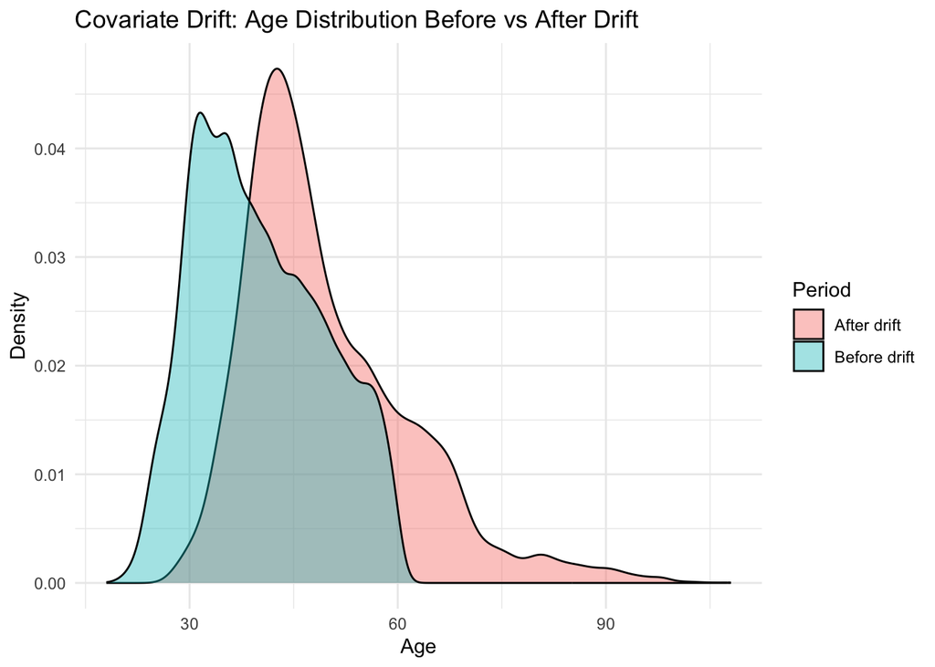

```r
cov_before <- stream_cov_drift %>%
filter(time_index < cov_drift_start) %>%
mutate(period = "Before drift")

cov_after <- stream_cov_drift %>%
filter(time_index >= cov_drift_start) %>%
mutate(period = "After drift")

cov_plot_data <- bind_rows(cov_before, cov_after)

ggplot(cov_plot_data, aes(x = age, fill = period)) +
geom_density(alpha = 0.4) +
labs(
title = "Covariate Drift: Age Distribution Before vs After Drift",
x = "Age",
y = "Density",
fill = "Period"
) +
theme_minimal()
```

We can clearly see that, after the drift point, the age distribution shifts to older clients.

### Label Drift: Positive Class Rate Over Time

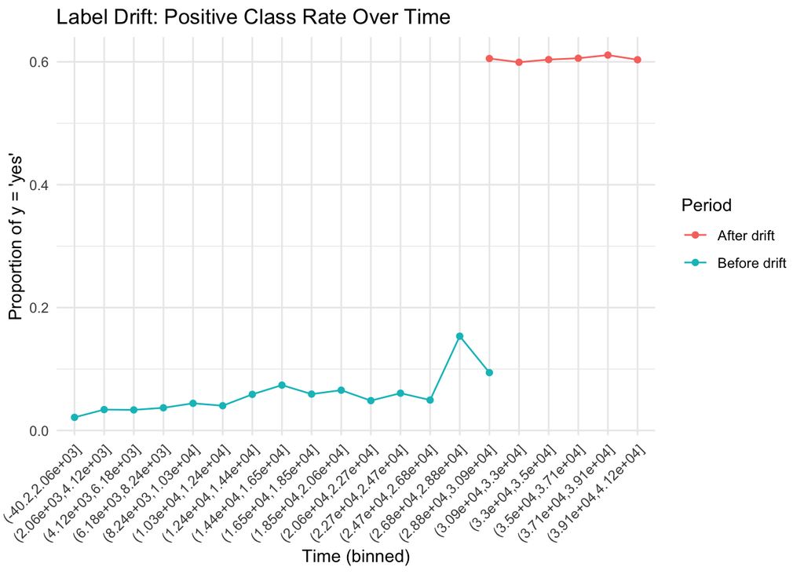

```r
label_plot_data <- stream_label_drift %>%
mutate(
period  = if_else(time_index < label_drift_start, "Before drift", "After drift"),
time_bin = cut(time_index, breaks = 20)
) %>%
group_by(period, time_bin) %>%
summarise(
yes_rate = mean(y == "yes"),
.groups  = "drop"
)

ggplot(label_plot_data,
aes(x = time_bin, y = yes_rate, group = period, colour = period)) +
geom_line() +
geom_point() +
labs(
title = "Label Drift: Positive Class Rate Over Time",
x = "Time (binned)",
y = "Proportion of y = 'yes'",
colour = "Period"
) +
theme_minimal() +
theme(axis.text.x = element_text(angle = 45, hjust = 1))
```

The plot shows a clear increase in the positive class rate after the drift point.

### Concept Drift: P(y = ‘yes’) as a Function of Age

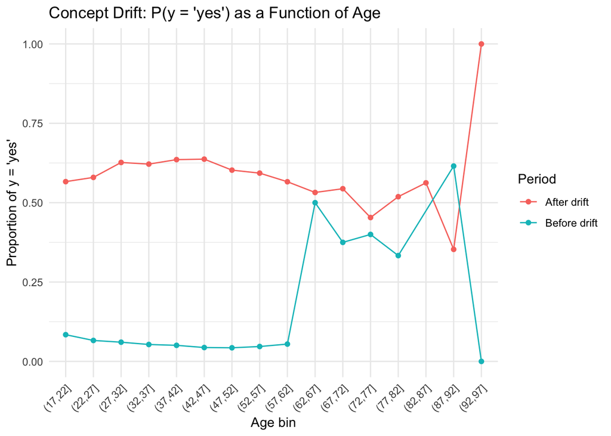

```r
concept_plot_data <- stream_concept_drift %>%
mutate(
period  = if_else(time_index < concept_drift_start, "Before drift", "After drift"),
age_bin = cut(age, breaks = seq(min(age), max(age), by = 5))
) %>%
group_by(period, age_bin) %>%
summarise(
yes_rate = mean(y == "yes"),
.groups  = "drop"
) %>%
filter(!is.na(age_bin))

ggplot(concept_plot_data,
aes(x = age_bin, y = yes_rate, group = period, colour = period)) +
geom_line() +
geom_point() +
labs(
title = "Concept Drift: P(y = 'yes') as a Function of Age",
x = "Age bin",
y = "Proportion of y = 'yes'",
colour = "Period"
) +
theme_minimal() +
theme(axis.text.x = element_text(angle = 45, hjust = 1))
```

Here, the relationship between age and the probability of a positive outcome changes between the pre-drift and post-drift periods, which is the hallmark of concept drift.

## Detecting the Drift

In a production system, we don’t know in advance when drift happens. Below I implement simple detectors for each drift type:

Covariate drift → rolling KS test on feature distributions

Label drift → rolling two-proportion Z-test on class rates

Concept drift → sliding-window model accuracy

### Covariate Drift Detection: Rolling KS Test

A rolling KS test detects covariate drift by repeatedly comparing the distribution of a feature in a sliding window with an earlier, stable reference window. Large KS statistics or small p-values indicate a change in distribution.

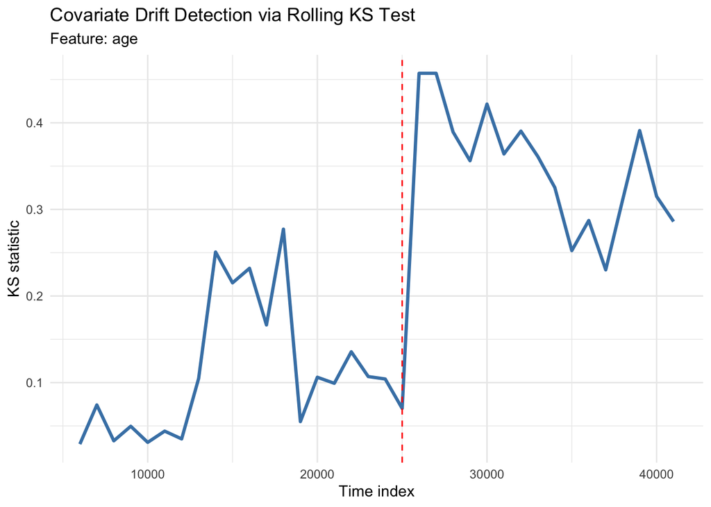

```r
rolling_ks_test <- function(df_stream,
feature = "age",
ref_end = 5000,
window  = 1000) {

  # reference distribution (before drift)

  ref_vec <- df_stream %>%
  filter(time_index <= ref_end) %>%
  pull({{ feature }})

  max_t <- max(df_stream$time_index)

  results <- map_dfr(
  seq(ref_end + window, max_t, by = window),
  function(t_end) {
    seg <- df_stream %>%
    filter(time_index > (t_end - window),
    time_index <= t_end) %>%
    pull({{ feature }})

    ks <- suppressWarnings(ks.test(ref_vec, seg))

    tibble(
      time_end = t_end,
      ks_stat  = ks$statistic,
      p_value  = ks$p.value
    )
  }

  )

  results
}

ks_results <- rolling_ks_test(
df_stream = stream_cov_drift,
feature   = "age",
ref_end   = 5000,
window    = 1000
)

ggplot(ks_results, aes(x = time_end, y = ks_stat)) +
geom_line(colour = "steelblue", linewidth = 1.1) +
geom_vline(xintercept = cov_drift_start, linetype = "dashed", colour = "red") +
labs(
title    = "Covariate Drift Detection via Rolling KS Test",
subtitle = "Feature: age",
x        = "Time index",
y        = "KS statistic"
) +
theme_minimal()
```

### Label Drift Detection: Rolling Two-Proportion Z-Test

For label drift, we monitor the positive class proportion in a sliding window and compare it to a reference period using a two-proportion Z-test.

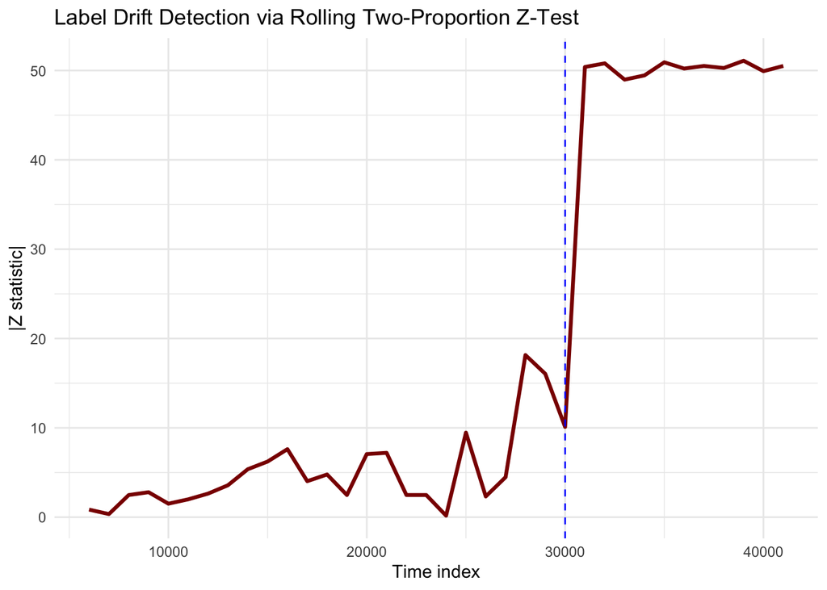

```r
rolling_label_ztest <- function(df_stream,
target         = "y",
ref_end        = 5000,
window         = 1000,
positive_class = "yes") {

# reference period

ref_vec <- df_stream %>%
filter(time_index <= ref_end) %>%
pull({{ target }})

p_ref <- mean(ref_vec == positive_class)
n_ref <- length(ref_vec)

max_t <- max(df_stream$time_index)

results <- map_dfr(
seq(ref_end + window, max_t, by = window),
function(t_end) {
  seg <- df_stream %>%
  filter(time_index > (t_end - window),
  time_index <= t_end) %>%
  pull({{ target }})

  p_seg <- mean(seg == positive_class)
  n_seg <- length(seg)

  # pooled proportion under H0: p_ref == p_seg
  p_pool <- (p_ref * n_ref + p_seg * n_seg) / (n_ref + n_seg)
  se     <- sqrt(p_pool * (1 - p_pool) * (1 / n_ref + 1 / n_seg))

  z       <- (p_ref - p_seg) / se
  p_value <- 2 * pnorm(abs(z), lower.tail = FALSE)

  tibble(
    time_end = t_end,
    p_ref    = p_ref,
    p_seg    = p_seg,
    z_stat   = z,
    p_value  = p_value
  )
}

)

results
}

z_results <- rolling_label_ztest(
df_stream      = stream_label_drift,
target         = "y",
ref_end        = 5000,
window         = 1000,
positive_class = "yes"
)

ggplot(z_results, aes(x = time_end, y = abs(z_stat))) +
geom_line(colour = "darkred", linewidth = 1.1) +
geom_vline(xintercept = label_drift_start,
linetype = "dashed",
colour   = "blue") +
labs(
title = "Label Drift Detection via Rolling Two-Proportion Z-Test",
x     = "Time index",
y     = "|Z statistic|"
) +
theme_minimal()
```

### Concept Drift Detection: Sliding-Window Model Accuracy

Concept drift affects the conditional distribution P(y∣X), so the most direct way to detect it is to monitor model performance over time.

I train a baseline model on the pre-drift data, then apply it to a sliding window across the full stream and track accuracy.

```r
# training set = before concept drift

train_data <- stream_concept_drift %>%
filter(time_index < concept_drift_start)

# simple random forest classifier on all features except time_index

set.seed(123)
rf_model <- ranger(
y ~ .,
data       = train_data %>% select(-time_index),
probability = TRUE
)
```

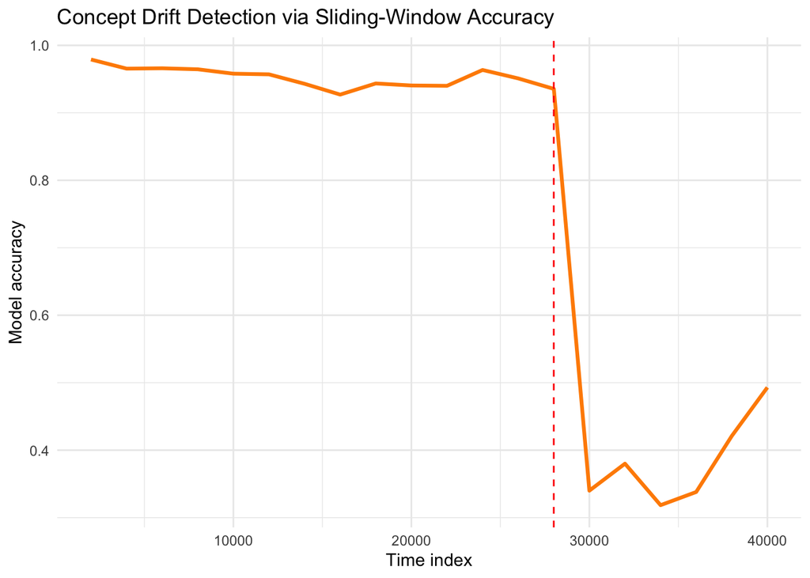

```r
rolling_performance <- function(df_stream,
model,
window         = 2000,
positive_class = "yes") {

max_t   <- max(df_stream$time_index)
results <- list()

for (t_end in seq(window, max_t, by = window)) {
seg <- df_stream %>%
filter(time_index > (t_end - window),
time_index <= t_end)

preds <- predict(model, seg %>% select(-y, -time_index))$predictions
pred_class <- ifelse(preds[, positive_class] > 0.5, "yes", "no")

accuracy <- mean(pred_class == seg$y)

results[[length(results) + 1]] <- tibble(
  time_end = t_end,
  accuracy = accuracy
)

}

bind_rows(results)
}

perf_results <- rolling_performance(
df_stream = stream_concept_drift,
model     = rf_model,
window    = 2000
)

ggplot(perf_results, aes(x = time_end, y = accuracy)) +
geom_line(colour = "darkorange", linewidth = 1.1) +
geom_vline(xintercept = concept_drift_start,
linetype = "dashed",
colour   = "red") +
labs(
title = "Concept Drift Detection via Sliding-Window Accuracy",
x     = "Time index",
y     = "Model accuracy"
) +
theme_minimal()
```

Accuracy remains high before the drift point, then drops sharply once concept drift is introduced, giving a clear performance-decay signal that the model is no longer well-calibrated to the current data.

## Why This Matters

This project demonstrates three important ideas for production ML systems:

- Different drift types need different detectors

– Covariate drift → monitor feature distributions (e.g., KS test, PSI)

– Label drift → monitor class proportions (e.g., two-proportion Z-test)

– Concept drift → monitor model performance (e.g., accuracy, AUC, calibration)

- Simulation is a powerful way to test monitoring strategies By injecting controlled drift into a real dataset, we can see how detectors behave, measure detection delay, and explore trade-offs between sensitivity and false alarms.
- These techniques are implementable with standard R tools All code here uses widely available R packages (tidyverse, ranger, purrr) and can be adapted to real-world monitoring dashboards and alerting systems.